# Run Time Analysis

```r
library(deSolve)
library(tictoc)
library(dplyr)
library(adaptivetau)
library(Matrix)
library(ggplot2)
library(tidyverse)
```

## ODE Models

### Parameters & Initialization

NOTE: $\beta_0$ will be estimated from $R_0$.

We will start by tuning the $\beta_0$ transmission rate. The `beta_matrix` function takes the number of subpopulations `patches` as an argument and returns a transmission matrix (patches-by-patches).

```r
beta_matrix <- function(patches, mu, sigma, gamma) {
  # Parameters
  rho <- 10^(-1)
  beta0 <- 0.91 # tuning parameter

  # beta matrix
  beta_mat <- matrix(rep(beta0, patches*patches), nrow=patches, ncol=patches)
  beta_mat[row(beta_mat) != col(beta_mat)] <- rho * beta0 / (patches - 1)

  # F matrix
  zero_mat <- matrix(rep(0, patches*patches), nrow=patches, ncol=patches)
  F_mat <- rbind(cbind(zero_mat, beta_mat), cbind(zero_mat, zero_mat))

  # V matrix
  tl_mat <- diag(rep(mu+sigma, patches), nrow=patches, ncol=patches)
  tr_mat <- matrix(rep(0, patches*patches), nrow=patches, ncol=patches)
  bl_mat <- diag(rep(-sigma, patches), nrow=patches, ncol=patches)
  br_mat <- diag(rep(mu+gamma, patches), nrow=patches, ncol=patches)
  V_mat <- rbind(cbind(tl_mat, tr_mat), cbind(bl_mat, br_mat))

  # NGM
  NGM <- F_mat %*% solve(V_mat)

  # R0
  r0 <- max(Re(eigen(NGM, only.values = TRUE)$values))
  return(beta_mat)
}
```

The function `pop_initializer` takes the number of patches `patches` as an argument and returns a list of vectors (S, E, I, R) with initial number of individuals in each class. The first patch is assumed to have one infected individual.

```r
pop_initializer <- function(patches) {
  S <- rep(10^6, patches)
  E <- rep(0, patches)
  I <- c(1, rep(0, patches-1))
  R <- rep(0, patches)

  return(purrr::map(1:patches, function(x) c(S[x], E[x], I[x], R[x])))
}
```

**Deterministic SEIR Model** The function `sim_SEIRV` takes the number of patches `patches`, the time frame in years `tf`, the initial population matrix `init` and the list of parameters `parms` as arguments and returns a time series of the infection throughout the metapopulation.

```r
sim_SEIR <- function(patches, tf, init, params) {

  # Set the variables of the model:
  variables <- unlist(purrr::map(seq(1, patches),
                               function(x) c(paste0("S", x), paste0("E", x), paste0("I", x), paste0("R", x))))
  # Vector of parameters
  parms_vector <- with(params, c(beta=beta, sigma=sigma, mu=mu, gamma=gamma))

  # Vector of initial conditions
  y0 <- unlist(purrr::map(seq(1, patches), function(x) c(init[x,])))
  names(y0) <- variables

  # This function models a time step for the SEIRV:
  dx.dt.SEIR <- function(t, y, parms) {

    patch <- function(j) {
      N <- y[paste0("S", j)] + y[paste0("E", j)] + y[paste0("I", j)] + y[paste0("R", j)]

      # Susceptible Individuals
      forceInfection <- sum(unlist(purrr::map(seq(1, patches), function(k) {parms[paste0("beta", patches*(j-1)+k)] * y[paste0("I", k)]})))
      dS <- parms["mu"]*N - forceInfection * y[paste0("S", j)]/N - parms["mu"] * y[paste0("S", j)]

      # Latent Individuals
      dE <- forceInfection * y[paste0("S", j)]/N - (parms["sigma"] + parms["mu"]) * y[paste0("E", j)]

      # Infectious Individuals
      dI <- parms["sigma"] * y[paste0("E", j)] - (parms["gamma"] + parms["mu"]) * y[paste0("I", j)]

      # Recovered Individuals
      dR <- parms["gamma"] * y[paste0("I", j)] - parms["mu"] * y[paste0("R", j)]

      return(c(dS, dE, dI, dR))
    }
    return (list(unlist((purrr::map(seq(1, patches), patch)))))
  }

  # Sequence of times at which we estimate
  times_vector <- seq(from=0, to=tf*365, by=1)

  # Run the ODE solver
  SEIRV.output <- as.data.frame(lsoda(y=y0, times=times_vector, func=dx.dt.SEIR, parms=parms_vector))
  return(SEIRV.output)
}
```

**Stochastic SEIR Framework** The function `sim_stochastic_SEIRV` takes the number of patches `patches`, the time frame in years `tf`, the initial population matrix `init` and the list of parameters `parms` as arguments and returns a time series of the infection throughout the metapopulation.

```r
sim_stochastic_SEIR <- function(patches, tf, init, params, f=adaptivetau::ssa.adaptivetau) {

  # vector of initial values
  x0 <- unlist(purrr::map(seq(1, patches), function(x) c(init[x,])))
  names(x0) <- unlist(purrr::map(seq(1, patches), function(x) c(paste0("S", x), paste0("E", x),
                                                          paste0("I", x), paste0("R", x))))

  # Transitions
  transitions <- list()
  for(x in 1:patches) {
    # Epi transitions
    tmp1 <- c(-1, +1)
    names(tmp1) <- c(paste0("S", x), paste0("E", x))
    tmp2 <- c(-1, +1)
    names(tmp2) <- c(paste0("E", x), paste0("I", x))
    tmp3 <- c(-1, +1)
    names(tmp3) <- c(paste0("I", x), paste0("R", x))

    # Birth transitions
    tmp4 <- c(+1)
    names(tmp4) <- c(paste0("S", x))

    # Death transitions
    tmp5 <- c(-1)
    names(tmp5) <- c(paste0("S", x))
    tmp6 <- c(-1)
    names(tmp6) <- c(paste0("E", x))
    tmp7 <- c(-1)
    names(tmp7) <- c(paste0("I", x))
    tmp8 <- c(-1)
    names(tmp8) <- c(paste0("R", x))

    transitions <- c(transitions, list(tmp1, tmp2, tmp3, tmp4, tmp5, tmp6, tmp7, tmp8))
  }

  # rate function.
  lvrates <- function(x, params, t){
    cityRates <- function(j) {with(c(x, params), {
      N <- x[paste0("S", j)] + x[paste0("E", j)] + x[paste0("I", j)] + x[paste0("R", j)]
      infectionRate <-
        sum(unlist(purrr::map(seq(1, patches),
                              function(k) beta[j, k] * x[paste0("I", k)])))
      c(infectionRate*x[paste0("S", j)]/N, sigma * x[paste0("E", j)], gamma * x[paste0("I", j)], mu * N,
        mu * x[paste0("S", j)], mu * x[paste0("E", j)], mu * x[paste0("I", j)], mu*x[paste0("R", j)])
    })}
    unlist(purrr::map(seq(1, patches), cityRates))
  }

  # simulation
  data.frame(f(init.values = x0, transitions = transitions, rateFunc = lvrates,
               params = c(patches=patches, params), tf = tf*365))
}
```

## Matrix Models

### Parameters

We will start by tuning the $\beta_0$ transmission rate. The `mat_beta_matrix` function takes the number of subpopulations `patches`, the birth rate `mu`, the latency rate `sigma`, the recovery rate `gamma`, and the survival probability `s` arguments and returns a transmission matrix (patches-by-patches).

```r
mat_beta_matrix <- function(patches, mu, sigma, gamma, s) {
  # Parameters
  rho <- 10^(-1)
  beta0 <- 1.83 # tuning parameter

  # beta matrix
  beta_mat <- matrix(rep(beta0, patches*patches), nrow=patches, ncol=patches)
  beta_mat[row(beta_mat) != col(beta_mat)] <- rho * beta0 / (patches - 1)

  # F matrix
  zero_mat <- matrix(rep(0, patches*patches), nrow=patches, ncol=patches)
  F_mat <- rbind(cbind(zero_mat, beta_mat*s), cbind(zero_mat, zero_mat))

  # V matrix
  tl_mat <- diag(rep(1 - s*(1-sigma), patches), nrow=patches, ncol=patches)
  tr_mat <- matrix(rep(0, patches*patches), nrow=patches, ncol=patches)
  bl_mat <- diag(rep(-s*sigma, patches), nrow=patches, ncol=patches)
  br_mat <- diag(rep(1 - s*(1-gamma), patches), nrow=patches, ncol=patches)
  V_mat <- rbind(cbind(tl_mat, tr_mat), cbind(bl_mat, br_mat))

  # NGM
  NGM <- F_mat %*% solve(V_mat)

  # R0
  r0 <- max(Re(eigen(NGM, only.values = TRUE)$values))
  return(beta_mat)
}
```

The function `generate_phi` takes the number of patches `patches`, the population vector `init`, the contact matrix `beta`, the survival rate `s`, the latency probability `sigma` and the recovery probability `gamma` as arguments and then returns the probability of infection vector.

```r
generate_phi <- function(patches, init, s, beta, sigma, gamma) {
  # Compute total populations
  ind <- purrr::map(1:patches, function(x) seq(x, patches*4, patches))
  N <- unlist(purrr::map(ind, function(x) sum(init[x])))

  # Extract infected vector
  I <- init[seq(1+2*patches, patches+2*patches)]

  # Compute the phi matrix
  phi <- unlist(purrr::map(1:patches, function(x) (1 - exp(-1/N[x]*sum(beta[x, ]*I)))))
  return(phi)
}
```

**Deterministic Matrix Approach** The function `sim_matrix_SEIRV` takes the number of patches `patches`, the time frame in years `tf`, the initial population list `init` and the list of parameters `parms` as arguments and returns a time series of the infection throughout the metapopulation.

```r
sim_matrix_SEIR <- function(patches, tf, init, params) {

  # Generate initial phi vector
  init.phi <- generate_phi(patches=patches, init=as.vector(do.call(rbind, init)), s=params$s,
                           beta=params$beta, sigma=params$sigma, gamma=params$gamma)

  # Initialize projection matrix
  A <- (params$s)*diag(c((1-init.phi), rep(1-params$sigma, patches), rep(1-params$gamma, patches), rep(1, patches)))
  A[row(A) - col(A) == patches] <- (params$s) * c(init.phi, rep(params$sigma, patches), rep(params$gamma, patches))

  # Generate birth matrix
  tmp <- as.vector(do.call(rbind, init))
  ind <- purrr::map(1:patches, function(x) seq(x, patches*4, patches))
  N <- unlist(purrr::map(ind, function(x) sum(tmp[x])))
  B <- c(params$mu*N, rep(0, 3*patches))

  # Initialize time series
  n <- as.vector(do.call(rbind, init))
  time.series <- matrix(data=c(0, n), nrow=1, ncol=(4*patches+1))


  # Indices for updating
  ind1 <- matrix(c(1:patches, 1:patches), nrow=patches, ncol=2)
  ind2 <- matrix(c((1:patches)+patches, 1:patches), nrow=patches, ncol=2)

  # Iterations
  for (i in seq(1, round(365/params$dt*tf), 1)) {
    # Project population forward
    n <- A %*% n + B
    time.series <- rbind(time.series, c(i, n))

    # Upate disease matrix (A)
    A[ind1] <- params$s*(1 - generate_phi(patches=patches, init=n, s=params$s,
                           beta=params$beta, sigma=params$sigma, gamma=params$gamma))
    A[ind2] <- params$s*generate_phi(patches=patches, init=n, s=params$s,
                           beta=params$beta, sigma=params$sigma, gamma=params$gamma)
    }
  time.series <- as.data.frame(time.series)
  time.series[,1] <- time.series[, 1]*params$dt

  # Let's format the time series
  names <- as.vector(do.call(rbind, purrr::map(1:patches, function(x)
    c(paste0("S", x), paste0("E", x), paste0("I", x), paste0("R", x)))))
  colnames(time.series) <- c("time", names)

  return(time.series)
}
```

**Stochastic Matrix Approach** The function `sim_stoch_matrix_SEIRV` takes the number of patches `patches`, the time frame in years `tf`, the initial population list `init` and the list of parameters `parms` as arguments and returns a time series of the infection throughout the metapopulation.

```r
sim_stoch_matrix_SEIR <- function(patches, tf, init, params) {

  # Generate initial phi vector
  init.phi <- generate_phi(patches=patches, init=as.vector(do.call(rbind, init)), s=params$s,
                           beta=params$beta, sigma=params$sigma, gamma=params$gamma)

  # Initialize projection matrix
  A <- (params$s)*diag(c((1-init.phi), rep(1-params$sigma, patches), rep(1-params$gamma, patches), rep(1, patches)))
  A[row(A) - col(A) == patches] <- (params$s) * c(init.phi, rep(params$sigma, patches), rep(params$gamma, patches))

  # Generate birth matrix
  tmp <- as.vector(do.call(rbind, init))
  ind <- purrr::map(1:patches, function(x) seq(x, patches*4, patches))
  N <- unlist(purrr::map(ind, function(x) sum(tmp[x])))
  B <- c(params$mu*N, rep(0, 3*patches))

  # Initialize time series
  n <- as.vector(do.call(rbind, init))
  time.series <- matrix(data=c(0, n), nrow=1, ncol=(4*patches+1))

  # Indices for updating
  ind1 <- matrix(c(1:patches, 1:patches), nrow=patches, ncol=2)
  ind2 <- matrix(c((1:patches)+patches, 1:patches), nrow=patches, ncol=2)

  # Iterations
  for (i in seq(1, round(365/params$dt*tf), 1)) {
    # Project the matrix forward
    tmp_A <- rbind(A, apply(A, 2, function(x) 1 - sum(x)))
    n <- rowSums(do.call(cbind, purrr::map(seq(1, 4*patches),
                                         function(x) rmultinom(n=1, size=n[x], prob=tmp_A[, x]))))[1:(4*patches)] + B
    time.series <- rbind(time.series, c(i, n))

    # Upate disease matrix (A)
    A[ind1] <- params$s*(1 - generate_phi(patches=patches, init=n, s=params$s,
                           beta=params$beta, sigma=params$sigma, gamma=params$gamma))
    A[ind2] <- params$s*generate_phi(patches=patches, init=n, s=params$s,
                           beta=params$beta, sigma=params$sigma, gamma=params$gamma)
    }
  time.series <- as.data.frame(time.series)
  time.series[,1] <- time.series[, 1]*params$dt

  # Let's format the time series
  names <- as.vector(do.call(rbind, purrr::map(1:patches, function(x)
    c(paste0("S", x), paste0("E", x), paste0("I", x), paste0("R", x)))))
  colnames(time.series) <- c("time", names)

  return(time.series)
}
```

## Comparison

```r
# Deterministic ODE Approach
f1 <- function(patches, tf) {
  mu <- 1/(70 * 365)
  sigma <- 1/8
  gamma <- 1/10
  tmp <- sim_SEIR(patches=patches, tf=tf, init=do.call(rbind, pop_initializer(patches)),
                  params=list(beta=beta_matrix(patches, mu=mu, sigma=sigma, gamma=gamma),
                              mu=mu, sigma=sigma, gamma=gamma))
  return(tmp)
}

# Stochastic ODE Approach
f2 <- function(patches, tf) {
  mu <- 1/(70 * 365)
  sigma <- 1/8
  gamma <- 1/10
  tmp <- sim_stochastic_SEIR(patches=patches, tf=tf, init=do.call(rbind,pop_initializer(patches=patches)),
                                           params=list(beta=beta_matrix(patches, mu=mu, sigma=sigma,
                                                                        gamma=gamma), mu=mu, sigma=sigma,
                                                       gamma=gamma))
  return(tmp)
}

# Deterministic Matrix Approach
f3 <- function(patches, tf) {
  dt <- 2
  sigma <- dt/8
  gamma <- dt/10
  mu <- 14/1000*dt/365
  s <- 1 - mu
  params <- list(beta=mat_beta_matrix(patches, mu=mu, sigma=sigma, gamma=gamma, s=s),
                 sigma=sigma, gamma=gamma, mu=mu, s=s, dt=dt)
  tmp <- sim_matrix_SEIR(patches=patches, tf=tf, init=pop_initializer(patches), params=params)
  return(tmp)
}

# Stochastic Matrix Approach
f4 <- function(patches, tf) {
  dt <- 2
  sigma <- dt/8
  gamma <- dt/10
  mu <- 14/1000*dt/365
  s <- 1 - mu
  params <- list(beta=mat_beta_matrix(patches, mu=mu, sigma=sigma, gamma=gamma, s=s),
                 sigma=sigma, gamma=gamma, mu=mu, s=s, dt=dt)
  tmp <- sim_stoch_matrix_SEIR(patches=patches, tf=tf, init=pop_initializer(patches), params=params)
  return(tmp)
}

# Simulations
patches <- 3
tf <- 1
det_sim <- f1(patches=patches, tf=tf)
stoch_sim <- f2(patches=patches, tf=tf)
mat_sim <- f3(patches=patches, tf=tf)
s_mat_sim <- f4(patches=patches, tf=tf)
```

Let’s graph these results:

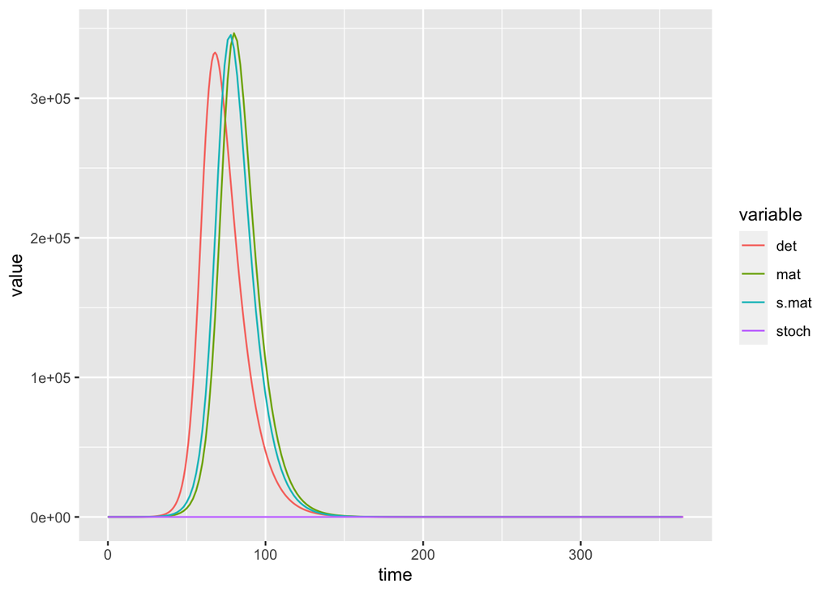

```r
# Graphing
library(reshape2)
det.melt<-melt(det_sim[,c("time", "I1")], id="time")
stoch.melt<-melt(stoch_sim[,c("time", "I1")], id="time")
mat.melt<-melt(mat_sim[,c("time", "I1")], id="time")
s.mat.melt<-melt(s_mat_sim[,c("time", "I1")], id="time")
det.melt[, "variable"] <- "det"
stoch.melt[, "variable"] <- "stoch"
mat.melt[, "variable"] <- "mat"
s.mat.melt[, "variable"] <- "s.mat"
data <- rbind(det.melt, stoch.melt, mat.melt, s.mat.melt)
library(ggplot2)
ggplot(data, aes(x=time,  y=value, colour=variable)) + geom_line()
```

## Run Time Analysis

```r
# Initialization
tf <- 1
patches <- c(seq(2, 50, by=2), seq(55, 70, by=5), seq(80, 100, 10))

# Let's time the deterministic case
times1 <- c()
for (i in patches) {
  reruns <- 3
  mu <- 1/(70 * 365)
  sigma <- 1/8
  gamma <- 1/10
  time <- median(unlist(purrr::rerun(reruns, {system.time(sim_SEIR(patches=i, tf=tf,
                                                      init=do.call(rbind, pop_initializer(patches=i)),
                 params=list(beta=beta_matrix(i, mu=mu, sigma=sigma,gamma=gamma), mu=mu, sigma=sigma,
                             gamma=gamma)))[3]})))
  times1 <- c(times1, time)
}

# Let's time the stochastic case
times2 <- c()
for (i in patches) {
  reruns <- 10
  mu <- 1/(70 * 365)
  sigma <- 1/8
  gamma <- 1/10
  time <- median(unlist(purrr::rerun(reruns, {system.time(sim_stochastic_SEIR(patches=i, tf=tf,
                                                                           init=do.call(rbind,pop_initializer(patches=i)),
                                                                           params=list(beta=beta_matrix(i, mu=mu,
                                                                                                        gamma=gamma,
                                                                                                        sigma=sigma),
                                                                                       mu=mu,sigma=sigma, gamma=gamma)))[3]})))
  times2 <- c(times2, time)
}

# Let's try the deterministic matrix case
times3 <- c()
for (i in patches) {
  reruns <- 10
  dt <- 2
  sigma <- dt/8
  gamma <- dt/10
  mu <- 14/1000*dt/365
  s <- 1 - mu
  params <- list(beta=mat_beta_matrix(i, sigma=sigma, gamma=gamma, mu=mu, s=s), sigma=sigma, gamma=gamma, mu=mu, s=s, dt=dt)
  time <- median(unlist(purrr::rerun(reruns, {system.time(sim_matrix_SEIR(patches=i, tf=tf, init=pop_initializer(i),
                                        params=params))[3]})))
  times3 <- c(times3, time)
}

times4 <- c()
for (i in patches) {
  reruns <- 20
  dt <- 2
  sigma <- dt/8
  gamma <- dt/10
  mu <- 14/1000*dt/365
  s <- 1 - mu
  params <- list(beta=mat_beta_matrix(i, sigma=sigma, gamma=gamma, mu=mu, s=s), sigma=sigma, gamma=gamma, mu=mu, s=s, dt=dt)
  time <- median(unlist(purrr::rerun(reruns, {system.time(sim_stoch_matrix_SEIR(patches=i, tf=tf, init=pop_initializer(i),
                                        params=params))[3]})))
  times4 <- c(times4, time)
}

running_times <- data.frame(patches=patches, det_ODE=times1, sto_ODE=times2, det_mat=times3, sto_mat=times4)
setwd(dir)
saveRDS(file="running_times", running_times)
```

```r
running_times <- readRDS(paste0(dir, "/running_times"))
patches <- running_times$patches
```

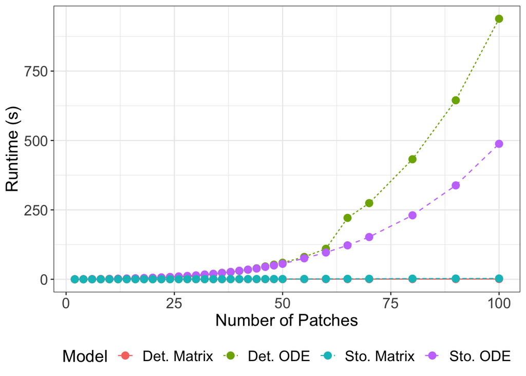

```r
running_times %>%
  setNames(c("Patch Number", "Det. ODE", "Sto. ODE", "Det. Matrix", "Sto. Matrix")) %>%
  gather(key = Model, value = run_time, 2:ncol(running_times)) %>%
  ggplot(aes(x=`Patch Number`, y=as.numeric(run_time), group=Model)) +
  geom_line(aes(linetype=Model, color=Model)) +
  geom_point(aes(color=Model), size=3) +
  labs(x="Number of Patches", y="Runtime (s)") +
  theme_bw() +
  theme(legend.position="bottom", legend.text = element_text(size = 14), legend.title = element_text(size = 16)) +
  theme(axis.text.x = element_text(size = 14), axis.title.x = element_text(size = 16),
        axis.text.y = element_text(size = 14), axis.title.y = element_text(size = 16))
```

```r
patches3 <- running_times$patches^4
cubic.model <- lm(running_times$det_ODE ~ patches3)
summary(cubic.model)
```

```
##
## Call:
## lm(formula = running_times$det_ODE ~ patches3)
##
## Residuals:
##     Min      1Q  Median      3Q     Max
## -30.228  -4.268  -2.061   0.127  43.729
##
## Coefficients:
##              Estimate Std. Error t value Pr(>|t|)
## (Intercept) 5.531e+00  2.779e+00    1.99   0.0558 .
## patches3    9.632e-06  1.197e-07   80.49   <2e-16 ***
## ---
## Signif. codes:  0 '***' 0.001 '**' 0.01 '*' 0.05 '.' 0.1 ' ' 1
##
## Residual standard error: 14.34 on 30 degrees of freedom
## Multiple R-squared:  0.9954, Adjusted R-squared:  0.9952
## F-statistic:  6478 on 1 and 30 DF,  p-value: < 2.2e-16
```

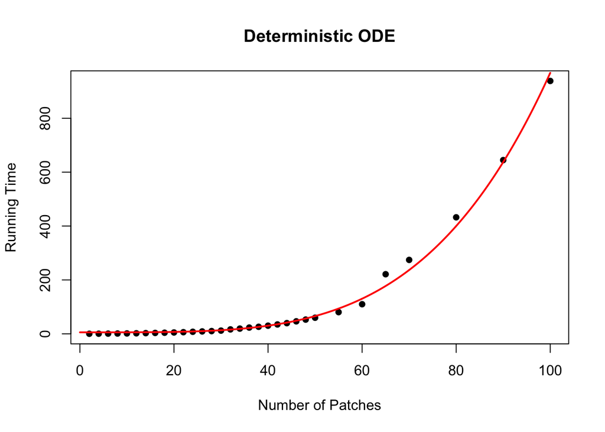

```r
x.values <- seq(0, 100, 0.1)
cubic.predictions <- predict(cubic.model, data.frame(patches3=x.values^4))
plot(running_times$patches, running_times$det_ODE, pch=16, xlab = "Number of Patches", ylab = "Running Time", main="Deterministic ODE")
lines(x.values, cubic.predictions, lwd=2, col = "red")
```

```r
patches3 <- running_times$patches^4
cubic.model <- lm(running_times$sto_ODE ~ patches3)
summary(cubic.model)
```

```
##
## Call:
## lm(formula = running_times$sto_ODE ~ patches3)
##
## Residuals:
##     Min      1Q  Median      3Q     Max
## -21.034  -9.562  -1.557   8.046  21.061
##
## Coefficients:
##              Estimate Std. Error t value Pr(>|t|)
## (Intercept) 1.263e+01  2.232e+00   5.658 3.64e-06 ***
## patches3    4.965e-06  9.609e-08  51.668  < 2e-16 ***
## ---
## Signif. codes:  0 '***' 0.001 '**' 0.01 '*' 0.05 '.' 0.1 ' ' 1
##
## Residual standard error: 11.51 on 30 degrees of freedom
## Multiple R-squared:  0.9889, Adjusted R-squared:  0.9885
## F-statistic:  2670 on 1 and 30 DF,  p-value: < 2.2e-16
```

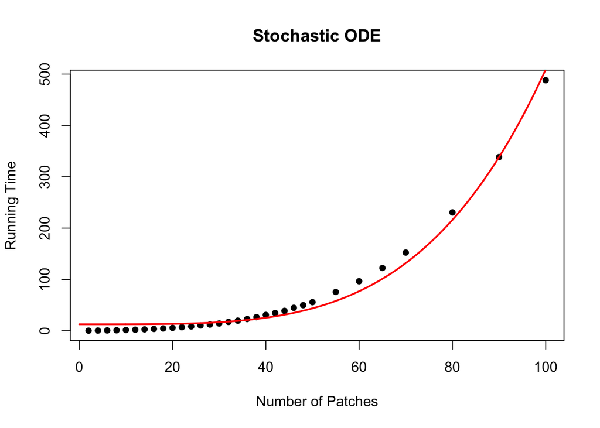

```r
x.values <- seq(0, 100, 0.1)
cubic.predictions <- predict(cubic.model, data.frame(patches3=x.values^4))
plot(patches, running_times$sto_ODE, pch=16, xlab = "Number of Patches", ylab = "Running Time", main="Stochastic ODE")
lines(x.values, cubic.predictions, lwd=2, col = "red")
```

**Deterministic Matrix**: The order of growth of running time is approximately linear.

```r
linear.model <- lm(running_times$det_mat ~ patches)
summary(linear.model)
```

```
##
## Call:
## lm(formula = running_times$det_mat ~ patches)
##
## Residuals:
##       Min        1Q    Median        3Q       Max
## -0.013470 -0.005646 -0.001961  0.003901  0.033151
##
## Coefficients:
##              Estimate Std. Error t value Pr(>|t|)
## (Intercept) 1.150e-02  3.106e-03   3.702  0.00086 ***
## patches     9.489e-03  7.037e-05 134.840  < 2e-16 ***
## ---
## Signif. codes:  0 '***' 0.001 '**' 0.01 '*' 0.05 '.' 0.1 ' ' 1
##
## Residual standard error: 0.009845 on 30 degrees of freedom
## Multiple R-squared:  0.9984, Adjusted R-squared:  0.9983
## F-statistic: 1.818e+04 on 1 and 30 DF,  p-value: < 2.2e-16
```

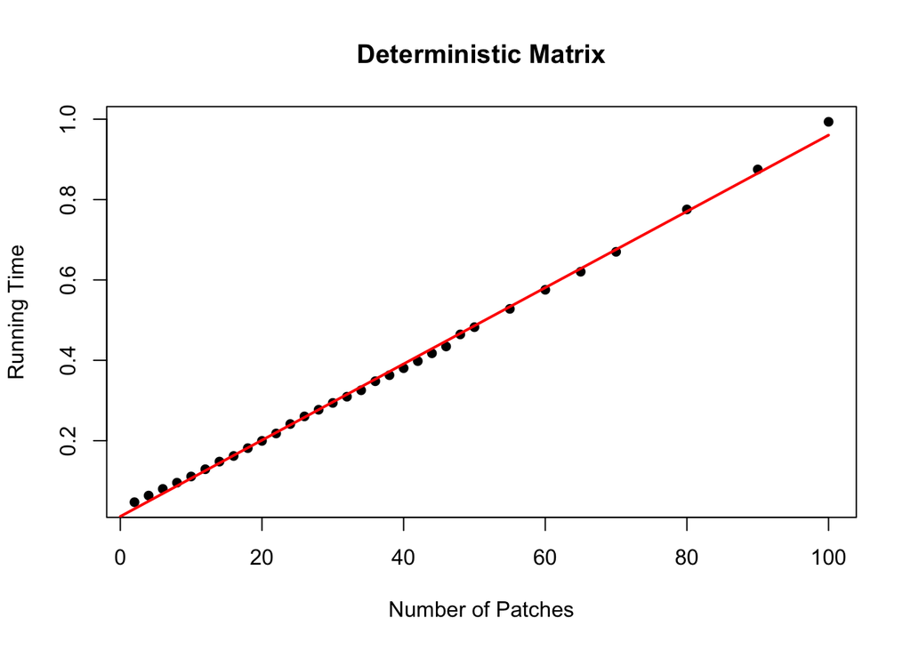

```r
x.values <- seq(0, 100, 0.1)
linear.predictions <- predict(linear.model, data.frame(patches=x.values))
plot(patches, running_times$det_mat, pch=16, xlab = "Number of Patches", ylab = "Running Time", main="Deterministic Matrix")
lines(x.values, linear.predictions, lwd=2, col = "red")
```

**Stochastic Matrix**: The order of growth of running time is approximately linear.

```r
linear.model <- lm(running_times$sto_mat ~ patches)
summary(linear.model)
```

```
##
## Call:
## lm(formula = running_times$sto_mat ~ patches)
##
## Residuals:
##       Min        1Q    Median        3Q       Max
## -0.155971 -0.125501 -0.009587  0.087466  0.268344
##
## Coefficients:
##               Estimate Std. Error t value Pr(>|t|)
## (Intercept) -0.1842908  0.0402038  -4.584 7.52e-05 ***
## patches      0.0290383  0.0009108  31.882  < 2e-16 ***
## ---
## Signif. codes:  0 '***' 0.001 '**' 0.01 '*' 0.05 '.' 0.1 ' ' 1
##
## Residual standard error: 0.1274 on 30 degrees of freedom
## Multiple R-squared:  0.9713, Adjusted R-squared:  0.9704
## F-statistic:  1016 on 1 and 30 DF,  p-value: < 2.2e-16
```

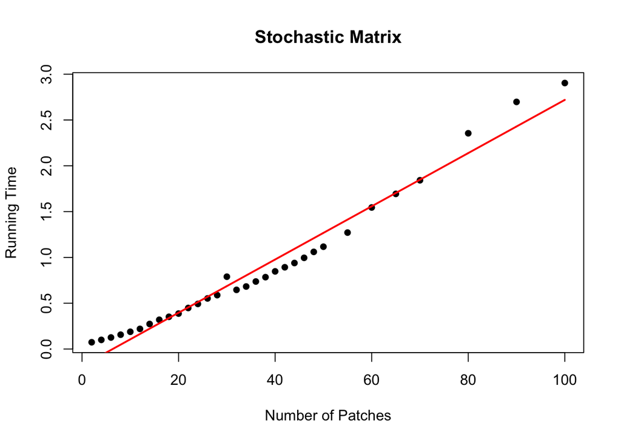

```r
x.values <- seq(0, 100, 0.1)
linear.predictions <- predict(linear.model, data.frame(patches=x.values))
plot(patches, running_times$sto_mat, pch=16, xlab = "Number of Patches", ylab = "Running Time", main="Stochastic Matrix")
lines(x.values, linear.predictions, lwd=2, col = "red")
```